# Trajectory inference

SECANT outputs single-cell clustering results and the probability that each cell belongs to its predicted cluster. These results provide ideal materials for single-cell trajectory inference and trajectory-based differential expression (DE) analysis. Here, we will demonstrate the use of [Slingshot](https://bioconductor.org/packages/devel/bioc/vignettes/slingshot/inst/doc/vignette.html)[1] for trajectory inference and [TradeSeq](https://statomics.github.io/tradeSeq/articles/tradeSeq.html)[2] for trajectory-based DE analysis, based on the SECANT analysis result on [10X10k PBMC dataset](https://support.10xgenomics.com/single-cell-gene-expression/datasets/3.0.0/pbmc_10k_protein_v3) (7865 cells). We will also illustrate how SECANT uncertainty output benefits downstream trajectory-based DE analysis.

# 1.Trajectory inference with Slingshot

```r
library(slingshot)
library(SingleCellExperiment)
library(tidyverse)
library(patchwork)
```

## 1.1 Loading data

We start by reading in the original UMI count matrix, SECANT clustering result, and SECANT posterior probability output. We recommend excluding uncertain cells before downstream analysis. Here, we set cut-off value to be 0.95, i.e., cells with the largest posterior cluster-specific probability < 0.95 will be excluded. After excluding uncertain cells, 87.4% of the cells remain in the dataset.

```r
data = readRDS("../Data/RNA.rds") #original UMI count matrix
data = as.matrix(data)
cluster_result = read.csv("../Data/cluster.csv") %>% rename("cluster" = "X..cluster")#SECANT clustering result
cluster_result = cluster_result %>%
    mutate(id = 1:nrow(cluster_result))
uncertainty = read.csv("../Data/10X10k_postP.csv") %>% rename("id" = "X") #SECANT posterior probability


#exclude uncertain cells, i.e., cells with the largest posterior cluster-specific probability < 0.95
cut_off = 0.95
certain_cells = uncertainty %>% filter(prob > cut_off)
nrow(certain_cells) / nrow(uncertainty) #proportion of remaining cells
```

```
## [1] 0.8738716
```

## 1.2 Slingshot on CD8+ T cells

To do trajectory inference, we use Slingshot, a single-cell trajectory inference method that can help to infer cell differentiation or activation process by ordering cells along a trajectory based on the similarities in their transcriptomic profiles. In a specific cell lineage, Slingshot defines cells with more similar transcriptomic profiles to be closer in “pseudotime”, and vice versa. In the 10X10k PBMC dataset, the CD8+ T-cell lineage, including CD8+ naive T cells, CD8+ effector T cells, and CD8+ memory T cells, is a cell lineage that goes through activation process and is suitable for trajectory inference. Therefore, we illustrate using Slingshot to do trajectory inference on the CD8+ T-cell lineage.

According to SECANT output, 1428 cells were annotated as CD8+ T cells. After excluding uncertain cells, 82.6% of the CD8+ T cells remain in the dataset.

```r
n_CD8 = nrow(cluster_result %>% filter(cluster %in% c(7,8,9))) #according to SECANT analysis result, cluster # 7, 8, and 9 corresponds to Memory CD8+ T cells, Naive CD8+ T cells, and Effector CD8+ T cells respectively


CD8_T_cells = cluster_result %>%
  filter(id %in% certain_cells$id) %>%
  filter(cluster %in% c(7,8,9))

nrow(CD8_T_cells) / n_CD8 #proportion of remaining CD8+ T cells
```

```
## [1] 0.8263305
```

Then, we input the UMI matrix and SECANT clustering result corresponds to these CD8+ T cells into Slingshot, which first identifies the global lineage structure with a cluster-based minimum spanning tree (MST) and then fit simultaneous principal curves to describe the lineage. The lineage identified and the pseudotimes estimated by Slingshot are visualized below.

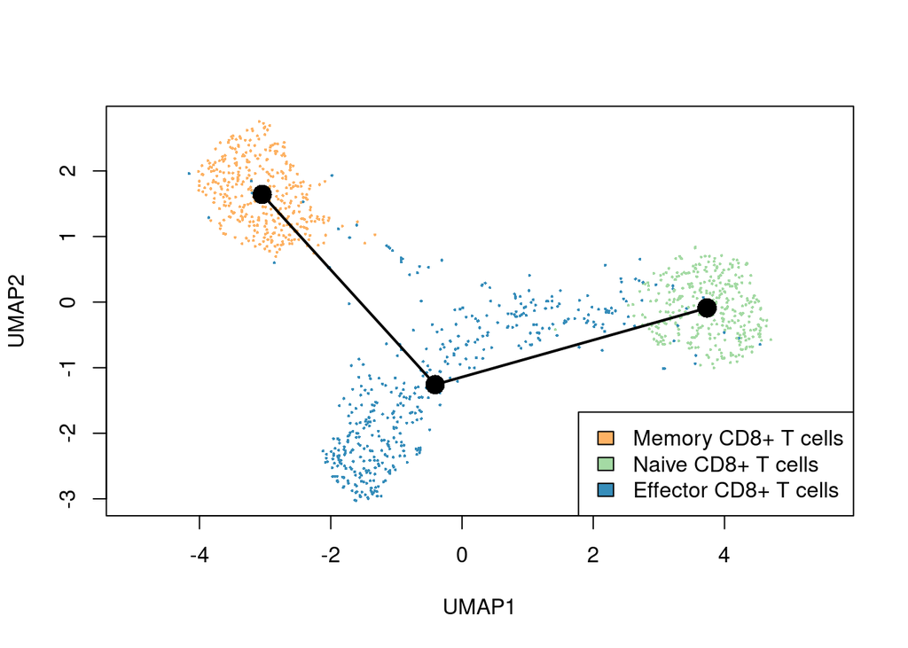

```r
data_CD8 = data[, CD8_T_cells$id]

sce <- SingleCellExperiment(assays = List(counts = data_CD8))

# filter genes down to potential cell-type markers
# at least M (5) reads in at least N (5) cells
geneFilter <- apply(assays(sce)$counts,1,function(x){
    sum(x >= 5) >= 5
})
sce <-sce[geneFilter, ]

FQnorm <- function(counts){
    rk <- apply(counts,2,rank,ties.method='min')
    counts.sort <- apply(counts,2,sort)
    refdist <- apply(counts.sort,1,median)
    norm <- apply(rk,2,function(r){ refdist[r] })
    rownames(norm) <- rownames(counts)
    return(norm)
}
assays(sce)$norm <- FQnorm(assays(sce)$counts)

set.seed(6)
rd2 <- uwot::umap(t(log1p(assays(sce)$norm)))
colnames(rd2) <- c('UMAP1', 'UMAP2')


colData(sce)$secant <- CD8_T_cells$cluster
cl1 = CD8_T_cells$cluster

reducedDims(sce) <- SimpleList(UMAP = rd2)
set.seed(6)
sce <- slingshot(sce, clusterLabels = 'secant', reducedDim = 'UMAP', approx_points = 150, start.clus = 8)

library(RColorBrewer)
library(grDevices)
colors <- colorRampPalette(brewer.pal(11,'Spectral')[-6])(100)


colors = colors[c(2,54,32,98,87,26,35,68,88,11,19)]
plot(rd2, col = colors[cl1], pch=16, asp = 1, cex = .3)
lines(SlingshotDataSet(sce), type = "l", lwd=2, col='black')
legend("bottomright", legend = c("Memory CD8+ T cells", "Naive CD8+ T cells", "Effector CD8+ T cells"), fill =colors[7:9])
```

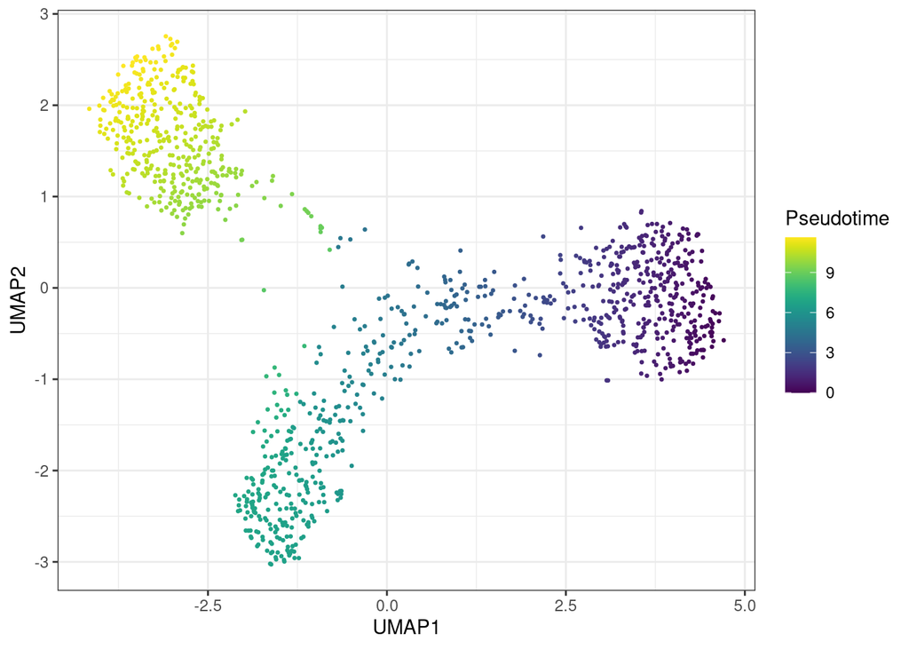

```r
pt = slingPseudotime(sce)
pt = pt %>% as.data.frame %>% mutate(id = 1:nrow(pt))

umap = rd2

data_plot = cbind(umap, pt)

data_plot %>% ggplot(aes(x = UMAP1, y = UMAP2, col = curve1)) + geom_point(size = .5) + viridis::scale_color_viridis(
    name = "Pseudotime"
  ) + theme_bw()
```

# 2. Differential expression across pseudotime

Downstream of Slingshot, we use the tradeSeq package to analyze gene expressions along trajectories. The pseudotime estimated by Slingshot is used as the input for tradeSeq.

```r
library(tradeSeq)
pseudotime <- slingPseudotime(sce, na = FALSE)
cellWeights <- slingCurveWeights(sce)
counts <- as.matrix(data_CD8[geneFilter,])
counts = rbind(counts, CCR7 = data_CD8[rownames(data_CD8)=="CCR7",])
crv = SlingshotDataSet(sce)
sce <- fitGAM(counts = counts, sds = crv, nknots = 15)
```

TradeSeq fits a spline model to express the expression of each gene as a function of pseudotime, and then we can create gene expression plots across pseudotime for any gene that converges in the model fitting process. Next, we will show the plots for a few genes for illustration purpose and to demonstrate the benefits of excluding uncertain cells.

According to biological backgroud knowledge, CCR7 and CCL5 are expressed at high levels in naive T cells and effector T cells, respectively. Therefore, we will show the expression of these two meaningful genes across pseudotime.

### 2.1 Gene expression across pseudotime after excluding uncertain CD8+ T cells

In this section, we simply plot the gene expression of CCR7 and CCL5 across pseudotime based on the analysis using only CD8+ T cells with high certainties, as shown above, and the we store the two plots in two ggplot objects for later comparison.

```r
CCL5_certain = plotSmoothers(sce, counts, gene = "CCL5") + ggtitle("CCL5 expression (exclude uncertain cells)") + theme(legend.position = "none")
CCR7_certain = plotSmoothers(sce, counts, gene = "CCR7") + ggtitle("CCR7 expression (exclude uncertain cells)") + theme(legend.position = "none")
```

### 2.2 Gene expression across pseudotime for all CD8+ T cells

In comparison, we do the same analysis workflow without excluding uncertain CD8+ T cells, and plot the expression of CCR7 and CCL5 across pseudotime.

```r
CD8_T_cells = cluster_result %>%
    filter(cluster %in% c(7,8,9))
data_CD8 = data[, CD8_T_cells$id]

sce_all <- SingleCellExperiment(assays = List(counts = data_CD8))

# filter genes down to potential cell-type markers
# at least M (5) reads in at least N (5) cells
geneFilter <- apply(assays(sce_all)$counts,1,function(x){
    sum(x >= 5) >= 5
})
sce_all <- sce_all[geneFilter, ]

assays(sce_all)$norm <- FQnorm(assays(sce_all)$counts)

set.seed(6)
rd2 <- uwot::umap(t(log1p(assays(sce_all)$norm)))
colnames(rd2) <- c('UMAP1', 'UMAP2')


colData(sce_all)$secant <- CD8_T_cells$cluster
cl1 = CD8_T_cells$cluster
library(RColorBrewer)

reducedDims(sce_all) <- SimpleList(UMAP = rd2)
set.seed(6)
sce_all <- slingshot(sce_all, clusterLabels = 'secant', reducedDim = 'UMAP', approx_points = 150, start.clus = 8, omega = TRUE)


pseudotime <- slingPseudotime(sce_all, na = FALSE)
cellWeights <- slingCurveWeights(sce_all)
counts_all <- as.matrix(data_CD8[geneFilter,])
counts_all = rbind(counts_all, CCR7 = data_CD8[rownames(data_CD8)=="CCR7",])
crv = SlingshotDataSet(sce_all)

sce_all <- fitGAM(counts = counts_all, sds = crv, nknots = 15)

CCL5 = plotSmoothers(sce_all, counts_all, gene = "CCL5") + ggtitle("CCL5 expression") + theme(legend.position = "none")


CCR7 = plotSmoothers(sce_all, counts_all, gene = "CCR7") + ggtitle("CCR7 expression") + theme(legend.position = "none")
```

### 2.3 Comparison

In this subsection, we compare the results generated by section 2.1 and section 2.2 to evaluate the impact of excluding uncertain cells.

CCR7 gene is expected to express at a high level in naive T cells, which correspond to cells that have pseudotimes close to 0. In the CCR7 expression plot on the top-left panel, there are several bumps. After excluding the uncertain cells, the analysis results presented by the top-right panel shows that the bumps are smoothed out, and that has better concordance with background biological knowledge.

CCL5 gene is expected to express at a high level in effector T cells, which correspond to cells that have pseudotimes roughly within the range of 3 to 9. By comparing the bottom two plots, we also find excluding uncertain cells smoothen the curve and may avoid falsely detecting gene expression trends.

```r
(CCR7 + CCR7_certain) / (CCL5 + CCL5_certain)
```

[figure not shown]

# Reference

[1] Street, K., Risso, D., Fletcher, R. et al. Slingshot: cell lineage and pseudotime inference for single-cell transcriptomics. BMC Genomics 19, 477 (2018). https://doi.org/10.1186/s12864-018-4772-0

[2] Van den Berge, K., Roux de Bézieux, H., Street, K. et al. Trajectory-based differential expression analysis for single-cell sequencing data. Nat Commun 11, 1201 (2020). https://doi.org/10.1038/s41467-020-14766-3